# Prediction

Statistical Programming with R

## Statistics vs Prediction

Statistics:

- hypothesis testing
  - significance of parameter estimates

Prediction:

- make predictions on new data set
  - machine learning (e.g. medical diagnosis)

## Prediction

Model training

- train the model using some algorithm (e.g. linear model)
- to predict the outcome on new data

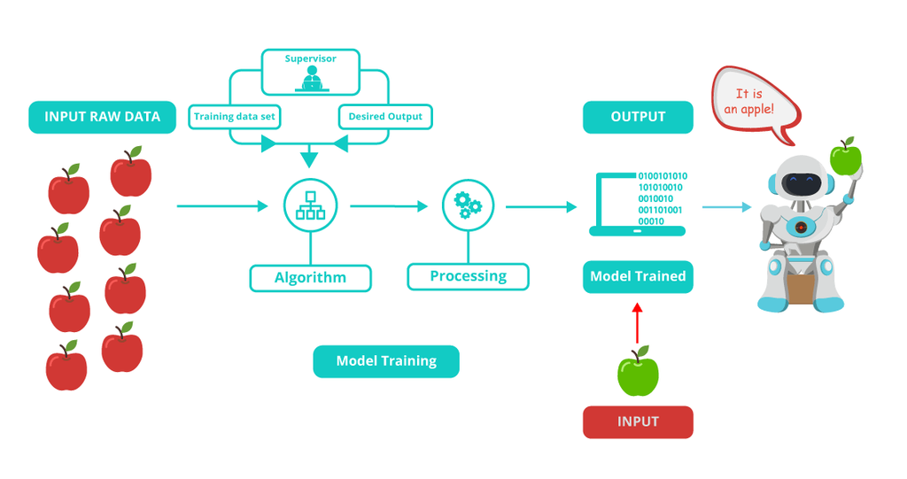

## Model training

- distinction between training data and new data
- aim is to predict outcome in new data set

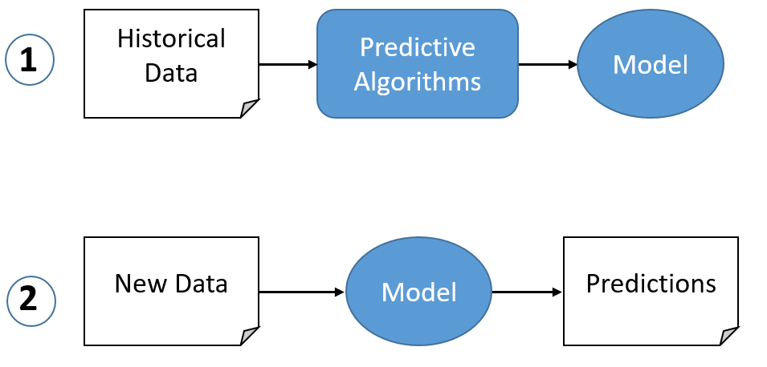

## Statistical models

**Mathematical representation of a theory**

\[y=f(x)+\epsilon\]

- \(y\) outcome/output/response/dependent variable
- \(x\) input/predictors/features
- \(f(x)\) prediction function
- \(\epsilon\) (irreducible) prediction error

## Competing \(f(x)\)

Many competing models

- linear models (least squares)
- nonlinear models
- tree-based methods
- support vector machines
- neural networks
- etc.

Models differ in complexity and interpretability

- related to number of parameters in the model

## Model complexity and interpretability

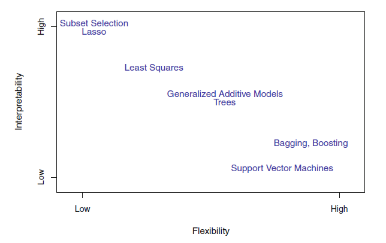

## Model choice

“All models are wrong, but some are useful” (George Box)

What is the best model choice?

- no a priori best model
- depends on the data
- try out alternatives, and select the best performing

But how to determine which one performs best???

## Mean Squared Error

Find the model with minimal MSE:

\[MSE =\frac{1}{n}\sum(y-f(x))^2= \frac{1}{n}\sum\varepsilon^2\]

- sum of squared differences between observations and predictions

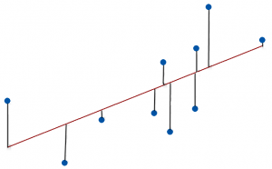

## Example

## Polynomial regression models

Increasing model complexity with polynomials

- Linear model (2 parameters)

\[f(x)=\beta_0+\beta{x}\]

- Quadratic model (3 parameters)

\[f(x)=\beta_0+\beta_1{x}+\beta_2x^2\]

- Cubic model (4 parameters)

\[f(x)=\beta_0+\beta_1{x}+\beta_2x^2+\beta_3x^3\]

etc.

## Data points generated from \(f(x)\)

What is \(f(x)\)? Is it . . .

- linear, quadratic, cubic, etc.?

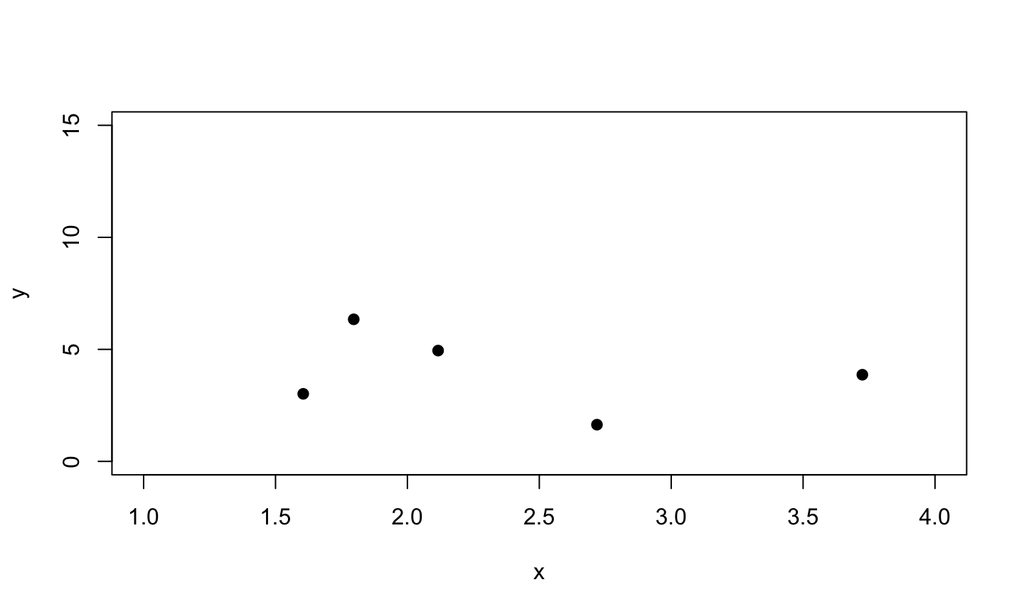

## Strategy for finding \(f(x)\)

Fit all polynomial models to the data

- compute the MSE for each model
- select the model with the smallest MSE

The model with the smallest MSE most resembles the true \(f(x)\).

**TRUE?**

## Predicted values for \(y\)

Regression lines linear, quadratic, cubic and quartic models

- quartic model fits data perfectly

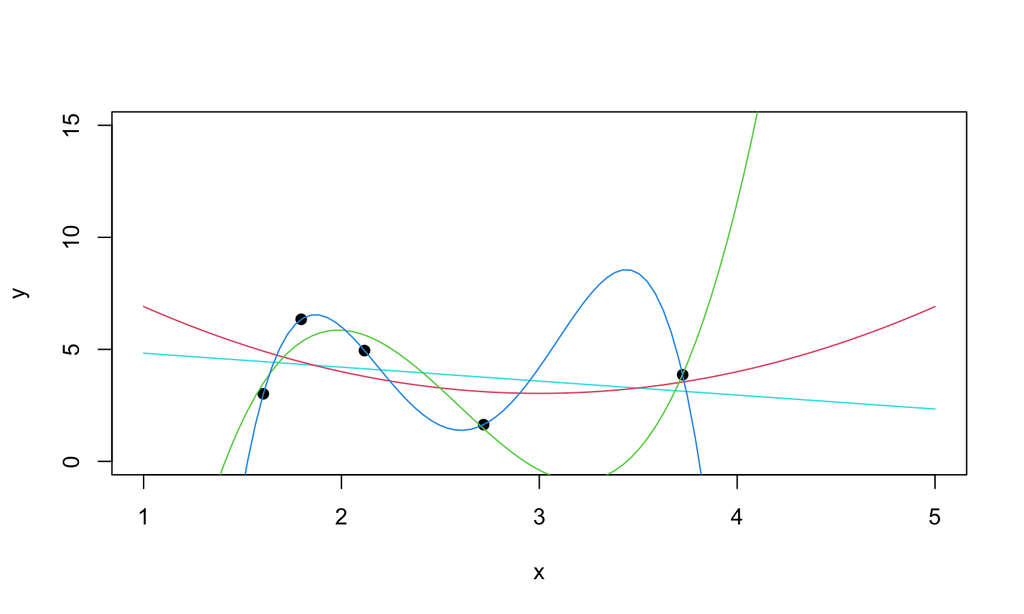

## MSE

Comparison of the MSE of the fitted models

| Fitted models | MSE | \(R^2\) |
| --- | --- | --- |
| linear | 2.3584 | 0.088 |
| quadratic | 2.1713 | 0.16 |
| cubic | 0.3526 | 0.864 |
| quartic | 0 | 1 |

**So the quartic model is the best????**

## Five new data points from \(f(x)\)

Regression lines for original five data points

- How well do the models fit to these new five data points?

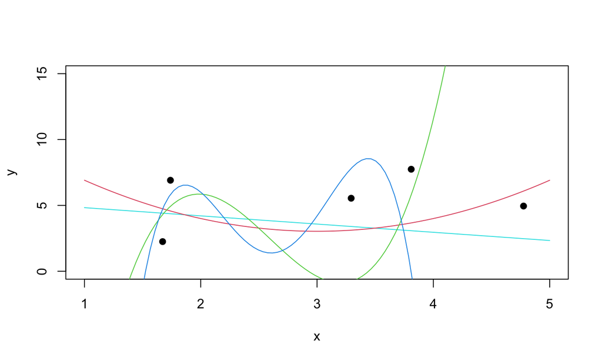

## MSE for new data points

MSE of the new data points show different picture!

| Fitted models | MSE |
| --- | --- |
| linear | 8.7 |
| quadratic | 7.1 |
| cubic | 658 |
| quartic | 11986.5 |

- quadratic model performs best
- quartic model performs terrible

## True \(f(x)\)

\[f(x)=2+x+\epsilon, \ \ \ \ \ \epsilon\sim N(0,4)\]

What did we not find the correct model with the MSE?

- simple models are biased (to few predictors)
- complex models have high variance (too many predictors)

## Bias vs variance

The expected MSE is composed of bias, variance and irreducible error

\[E(MSE) = bias^2 + variance + \sigma^2\]

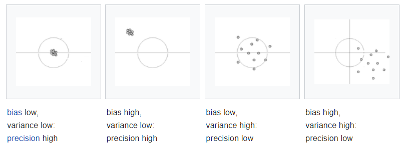

## MSE vs model complexity

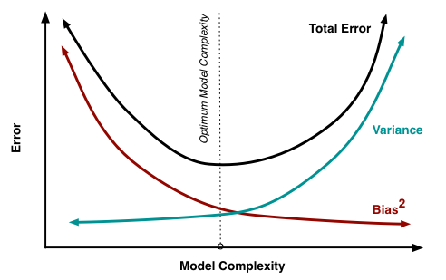

## Cross validation

Method to find optimal model complexity

- Split the data in folds (training and test sets)
  - fit the model to the training sets
  - compute the MSE on the test sets
  - select model with lowest test MSE

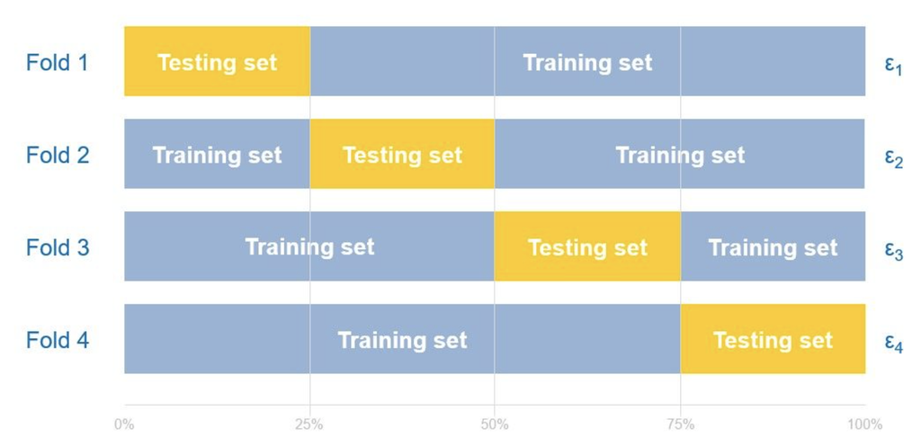

## 5-fold cross validation on example data

We will program it ourselves

- this the original example data set

```r
d
```

```
##          x        y
## 1 1.796526 6.341385
## 2 2.116372 4.945655
## 3 2.718560 1.638660
## 4 3.724623 3.867489
## 5 1.605046 3.015605
```

## Folds and training and test sets

Getting the indices for the test sets

- with 5-fold cross validation we need 5 test sets

Use `sample()` to make random test sets

```r
folds   <- 5
row_id  <- 1:5
test_id <- split(x = row_id, f = 1:5)  # f is fold 1 to 5
test_id                                # test_id is a list
```

```
## $`1`
## [1] 1
##
## $`2`
## [1] 2
##
## $`3`
## [1] 3
##
## $`4`
## [1] 4
##
## $`5`
## [1] 5
```

## Training and test sets

```r
d[test_id[[1]], ]
```

```
##          x        y
## 1 1.796526 6.341385
```

```r
d[-test_id[[1]], ]
```

```
##          x        y
## 2 2.116372 4.945655
## 3 2.718560 1.638660
## 4 3.724623 3.867489
## 5 1.605046 3.015605
```

## Get the test MSE

1. train the models on the five training sets
2. get the predictions on the test set
3. compute and store the test MSE

Example for the linear model and the first fold

```r
mse_lin    <- matrix(nrow = folds)                    # for storing test MSE's

fit        <- lm(y ~ x, data = d[-test_id[[1]], ])      # fit model to training set

pred       <- predict(fit, newdata = d[test_id[[1]], ]) # get prediction on test set

mse_lin[1] <- mean((d$y[test_id[[1]]] - pred)^2)         # compute test MSE

mse_lin
```

```
##          [,1]
## [1,] 8.748547
## [2,]       NA
## [3,]       NA
## [4,]       NA
## [5,]       NA
```

## Now for the 2nd fold

```r
fit        <- lm(y ~ x, data = d[-test_id[[2]], ])      # fit model to training set

pred       <- predict(fit, newdata = d[test_id[[2]], ]) # get prediction on test set

mse_lin[2] <- mean((d$y[test_id[[2]]] - pred)^2)         # compute test MSE

mse_lin
```

```
##          [,1]
## [1,] 8.748547
## [2,] 1.100311
## [3,]       NA
## [4,]       NA
## [5,]       NA
```

## Using a `for` loop

Writing the code for 5 folds is cumbersome

- we can do it more efficiently with a `for` loop

```r
mse_lin    <- matrix(nrow = folds)

for (i in 1:folds) {     # i takes the value of the consecutive folds

  fit        <- lm(y ~ x, data = d[-test_id[[i]], ])

  pred       <- predict(fit, newdata = d[test_id[[i]], ])

  mse_lin[i] <- mean((d$y[test_id[[i]]] - pred)^2)     # test MSE of the i-th fold

}

mse_lin
```

```
##           [,1]
## [1,]  8.748547
## [2,]  1.100311
## [3,]  7.703967
## [4,] 14.315792
## [5,]  5.957239
```

## For the quadratic model

```r
mse_quad    <- matrix(nrow = folds)

for (i in 1:folds) {     # i takes the value of the consecutive folds

  fit         <- lm(y ~ poly(x, 2), data = d[-test_id[[i]], ])     # poly(x, 2) is x + x^2

  pred        <- predict(fit, newdata = d[test_id[[i]], ])

  mse_quad[i] <- mean((d$y[test_id[[i]]] - pred)^2)     # test MSE of the i-th fold

}

mse_quad
```

```
##            [,1]
## [1,]   8.133892
## [2,]   3.153669
## [3,]  21.568271
## [4,] 629.114316
## [5,]  29.080438
```

## For the cubic model

```r
mse_cub   <- matrix(nrow = folds)

for (i in 1:folds) {

  fit        <- lm(y ~ poly(x, 3), data = d[-test_id[[i]], ])

  pred       <- predict(fit, newdata = d[test_id[[i]], ])

  mse_cub[i] <- mean((d$y[test_id[[i]]] - pred)^2)

}

mse_cub
```

```
##              [,1]
## [1,]     3.041523
## [2,]     6.436648
## [3,]    99.268457
## [4,] 11218.260959
## [5,]    13.700736
```

## For the quartic model

We can’t fit the quartic model

- there are only 4 data points left in the training set
- there are at least 5 data points required for the quartic model

With larger data sets this would not be a problem

## Comparing the test MSE’s

```r
data.frame(linear    = mean(mse_lin),
           quadratic = mean(mse_quad),
           cubic     = mean(mse_cub),
           row.names = "Average test MSE")
```

```
##                    linear quadratic    cubic
## Average test MSE 7.565171  138.2101 2268.142
```

So with cross validation we find the correct model

- select the linear model for prediction on new data set

## Practical

Perform cross validation on the `cars` data set

- Is the stopping distance of a car a linear, quadratic or cubic function of the speed?